*Note: The city of Chicago buys goods and services from the local vendors. The actual purchases are made by the various Departments within the city government.

# 1. Objectives of This Analysis

- First, I decided to look at the data from the point of view of an investigator *looking for corrupt purchasing behavior*. The results from this analysis are in Section 3.
- In Section 3.1, I looked at the data from a **political point of view**, where I analyzed total payment amounts for all years, departments and vendors and ckecked if there is any pattern for changes since Rahm Emanuel took office in 2011.
- My purpose in Section 3.2 was finding vendors that received the highest amount of US dollars from departments.
- Section 3.3 includes analysis for vendors that were receiving payments through contract or *direct vendors* (no contract or paid by cash).
- Because payments from *1996* through *2002* have been rolled-up and *appear as "2002"* in the data, I devided the data set into two data sets and investigated them separately as before 2002, and after 2002. Then, I drilled it down to analyze the total dollars paid by department for every vendor for the years:  
  1) 1996-2002  
  2) 2002-2018

# 2. Reading In and Checking the Quality of the Payments Data

```python
import numpy as np
import pandas as pd
import seaborn as sns
import matplotlib.pyplot as plt
from matplotlib.pyplot import figure
%matplotlib inline
import warnings
warnings.filterwarnings('ignore')
import datetime
from matplotlib.ticker import FuncFormatter
```

```python
payments = pd.read_csv('Payments.csv', low_memory=False)
```

```python
payments.head()
```

|  | VOUCHER NUMBER | AMOUNT | CHECK DATE | DEPARTMENT NAME | CONTRACT NUMBER | VENDOR NAME | CASHED |
| --- | --- | --- | --- | --- | --- | --- | --- |
| 0 | PV99189986031 | 50.00 | 04/06/2018 | NaN | DV | HATCHETT, SYDELL | True |
| 1 | PVRF182700008 | 29.14 | 09/05/2018 | NaN | DV | NOEMI GALVEZ-DELIRA | True |
| 2 | PVRF182700007 | 29.14 | 09/04/2018 | NaN | DV | ANTONIO REED | True |
| 3 | PVCI19CI500124 | 137607.50 | 03/11/2019 | DEPT OF BUSINESS & INFORMATION SERVICES | 32678 | CARMINATI CONSULTING | True |
| 4 | PV991999612973 | 43878.68 | 03/05/2019 | NaN | DV | RUSH SURGICENTER LTD | True |

```python
payments.info()
```

```
<class 'pandas.core.frame.DataFrame'>
RangeIndex: 797256 entries, 0 to 797255
Data columns (total 7 columns):
VOUCHER NUMBER     646912 non-null object
AMOUNT             797256 non-null float64
CHECK DATE         797256 non-null object
DEPARTMENT NAME    123421 non-null object
CONTRACT NUMBER    797256 non-null object
VENDOR NAME        797246 non-null object
CASHED             786199 non-null object
dtypes: float64(1), object(6)
memory usage: 42.6+ MB
```

```python
payments.shape
```

```
(797256, 7)
```

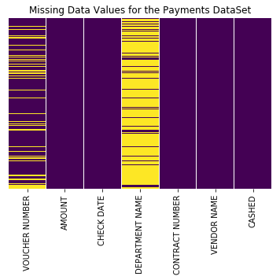

```python
ax = sns.heatmap(payments.isnull(),yticklabels=False,cbar=False,cmap='viridis')
ax.set_title("Missing Data Values for the Payments DataSet")
```

### *Almost 85% of the department_name column's values is lost.*

```python
sum_missing = payments.isnull().sum()
percent_missing = payments.isnull().sum() * 100 / len(payments)

missing_value_df = pd.DataFrame({'column_name': payments.columns,
                                 'total_missing':sum_missing,
                                 'percent_missing': percent_missing})
missing_value_df
```

|  | column_name | percent_missing | total_missing |
| --- | --- | --- | --- |
| VOUCHER NUMBER | VOUCHER NUMBER | 18.857682 | 150344 |
| AMOUNT | AMOUNT | 0.000000 | 0 |
| CHECK DATE | CHECK DATE | 0.000000 | 0 |
| DEPARTMENT NAME | DEPARTMENT NAME | 84.519276 | 673835 |
| CONTRACT NUMBER | CONTRACT NUMBER | 0.000000 | 0 |
| VENDOR NAME | VENDOR NAME | 0.001254 | 10 |
| CASHED | CASHED | 1.386882 | 11057 |

```python
payments.drop("VOUCHER NUMBER", axis=1, inplace=True)
```

```python
payments.rename(columns={'AMOUNT':'amount', 'CHECK DATE':'check_date',
                         'CONTRACT NUMBER':'contract_number',
                         'DEPARTMENT NAME':'department_name',
                         'VENDOR NAME':'vendor_name','CASHED':'cashed'},
               inplace=True)
```

```python
payments["check_date"] = pd.to_datetime(payments["check_date"])

payments['year'] = payments["check_date"].dt.year
payments['month'] = payments["check_date"].dt.month
payments['weekday'] = payments["check_date"].dt.weekday

payments.drop("check_date", axis=1, inplace=True)
```

```python
payments.head()
```

|  | amount | department_name | contract_number | vendor_name | cashed | year | month | weekday |
| --- | --- | --- | --- | --- | --- | --- | --- | --- |
| 0 | 50.00 | NaN | DV | HATCHETT, SYDELL | True | 2018 | 4 | 4 |
| 1 | 29.14 | NaN | DV | NOEMI GALVEZ-DELIRA | True | 2018 | 9 | 2 |
| 2 | 29.14 | NaN | DV | ANTONIO REED | True | 2018 | 9 | 1 |
| 3 | 137607.50 | DEPT OF BUSINESS & INFORMATION SERVICES | 32678 | CARMINATI CONSULTING | True | 2019 | 3 | 0 |
| 4 | 43878.68 | NaN | DV | RUSH SURGICENTER LTD | True | 2019 | 3 | 1 |

```python
payments_before_2002 = payments.loc[payments.year == 2002]
print(payments_before_2002["amount"].sum())
print("\n")
print(payments_before_2002["amount"].sum()/7)
```

```
11120745925.45


1588677989.3500001
```

```python
payments_after_2002 = payments.loc[payments.year > 2002]
print(payments_after_2002["amount"].sum())
print("\n")
print(payments_after_2002["amount"].sum()/16)
```

```
79800684681.70004


4987542792.606253
```

# 3. Exploring and Visualizing the Payments Data.

## 3.1 Analyzing data from a political point of view.

- Looking at the city expenditures *before and after 2002* (Fig. 3.1.1).
- Analyzing how the *city expenditures* have been evolving since 2003 (Fig. 3.1.2).
- The total dollars paid by the *top 15 departments* for **all the orders** for the years 1996-2018 (Fig. 3.1.3).
- Investigation of total dollars paid for vendors by *Department of Finance for 2003-2018* (Fig. 3.1.4).
- The total dollars paid by the *top 15 departments* for *small orders only* for the years 2003-2018 (Fig. 3.1.5).
- *The total dollars paid by year* for the *top five departments* for all orders for 2003-2018 (Fig. 3.1.6/3.1.6(a)).
- Top six vendors paid by department of Water Management for the Years 2003-2018 (Fig. 3.1.7).

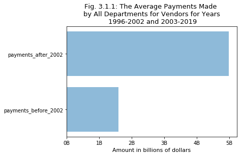

```python
data = ("payments_before_2002", "payments_after_2002")
y_pos = np.arange(len(data))
amount = [1588677989.3500001, 4987542792.606253]

plt.barh(y_pos, amount, align='center', alpha=0.5)
plt.yticks(y_pos, data)
plt.xlabel('Amount in billions of dollars', fontsize=11)
plt.title("Fig. 3.1.1: The Average Payments Made \n by All Departments for Vendors for Years \n 1996-2002 and 2003-2019", fontsize=13)

def billions(val, pos):
    return f'{val*1e-9:.0f}B'

formatter = FuncFormatter(billions)
plt.gca().xaxis.set_major_formatter(formatter)
```

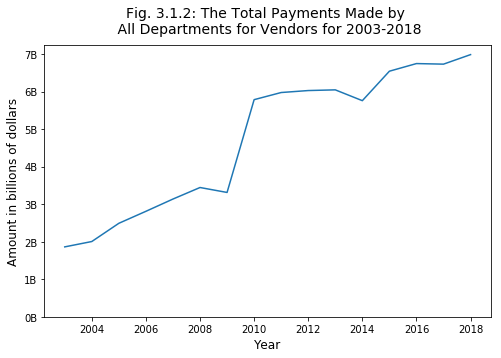

```python
payments_by_year = payments.groupby(['year']).amount.sum()
payments_by_year.loc[(payments_by_year.index >2002)&(payments_by_year.index != 2019)].plot(kind="line", y="amount", figsize=(8,5))
plt.ylim(bottom=0)

plt.xlabel("Year", fontsize=12)
plt.ylabel("Amount in billions of dollars", fontsize=12)
plt.title("Fig. 3.1.2: The Total Payments Made by \n All Departments for Vendors for 2003-2018", y=1.02, fontsize=14)
def billions(val, pos):
    return f'{val*1e-9:.0f}B'

formatter = FuncFormatter(billions)
plt.gca().yaxis.set_major_formatter(formatter)
```

- If departments are buying in amounts of over a \$100.000, it's considered a *"Large Order"*.
- If departments are buying in amounts of under a \$100,000, it's considered a *"Small Order"*.

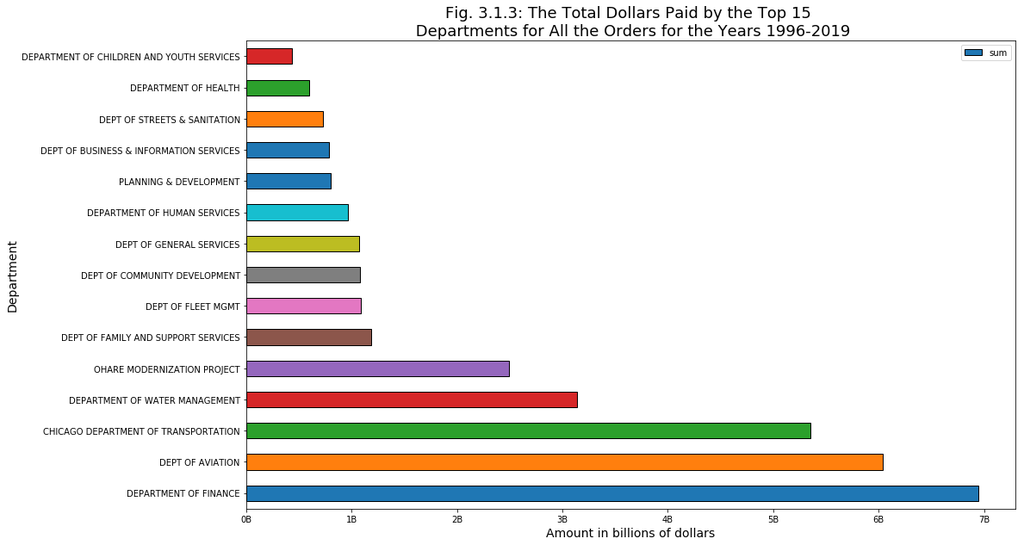

```python
grouped_by_dept = payments[payments["department_name"].notnull()]
grouped_by_dept = grouped_by_dept.groupby("department_name").amount.sum().sort_values(ascending=False).reset_index(name='sum').head(15)
grouped_by_dept.plot.barh(x="department_name", y='sum', figsize=(16,10), edgecolor="black")
plt.xlabel("Amount in billions of dollars", fontsize=14)
plt.ylabel("Department", fontsize=14)

plt.title("Fig. 3.1.3: The Total Dollars Paid by the Top 15 \n Departments for All the Orders for the Years 1996-2019", fontsize=18)
def billions(val, pos):
    return f'{val*1e-9:.0f}B'

formatter = FuncFormatter(billions)
plt.gca().xaxis.set_major_formatter(formatter)
```

*Observation: Department of finance has the highest payments followed by the department of aviation for 1996 - 2019.*  
This plot also represents departments that have the highest payments for large orders.

Note: Consider that we have only 15% available data for the department_name column.

```python
dept_finance = payments.loc[payments.department_name == "DEPARTMENT OF FINANCE"]
```

```python
top_four = dept_finance.loc[dept_finance.vendor_name.isin(["BLUE CROSS & BLUE SHIELD", "IBM CORPORATION ",
                                  "GLADYS R. WILSON & ASSOCIATES PC", "SEAWAY BANK & TRUST COMPANY",
                                  "A & O RECOVERY SOLUTIONS, LLC."])].groupby(["year",
                                                          "vendor_name"]).amount.sum().unstack()
top_four.fillna(0, inplace=True)
```

[figure not shown]

```python
top_four.plot.line(figsize=(18,10))

plt.xlabel("Year", fontsize=14)
plt.ylabel("Amount in millions of dollars", fontsize=14)
plt.title("Figure 3.1.4: The Total Dollars Paid by Year by Department of Finance for the\n Top Four Departments for All Orders for 2003-2018", fontsize=20)

def millions(val, pos):
    return f'{val*1e-6:.0f}M'

formatter = FuncFormatter(millions)
plt.gca().yaxis.set_major_formatter(formatter)
```

*Observation: It's clear that primary purpose of the Department of Finance is to pay Health Insurance.*

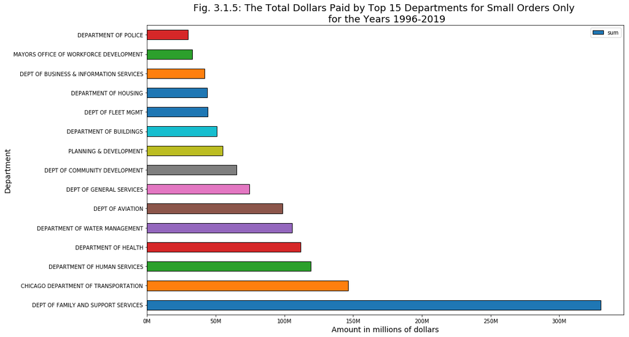

```python
small_order = payments[(payments["amount"]<100000)&(payments["department_name"].notnull())]
small_order = small_order.groupby("department_name").amount.sum().sort_values(ascending=False).reset_index(name='sum').head(15)
small_order.plot.barh(x="department_name", y='sum', figsize=(16, 10), edgecolor="black")
plt.xlabel("Amount in millions of dollars", fontsize=14)
plt.ylabel("Department", fontsize=14)
plt.title('Fig. 3.1.5: The Total Dollars Paid by Top 15 Departments for Small Orders Only \n for the Years 1996-2019', fontsize=18)
def millions(val, pos):
    return f'{val*1e-6:.0f}M'

formatter = FuncFormatter(millions)
plt.gca().xaxis.set_major_formatter(formatter)
```

*Observation: Department of family and support services has the highest payments for small orders only for 1996 and 2019*.

```python
top_five_dept = payments.loc[(payments.department_name.isin(["DEPARTMENT OF FINANCE",
                                                                 "DEPT OF AVIATION",
                                                                 "CHICAGO DEPARTMENT OF TRANSPORTATION",
                                                                 "DEPARTMENT OF WATER MANAGEMENT",
                                                                 "OHARE MODERNIZATION PROJECT"]))&
                             (payments.year != 2002) & (payments.year != 2019)].groupby(["year",
                                                          "department_name"]).amount.sum().unstack()
top_five_dept.fillna(0, inplace=True)
```

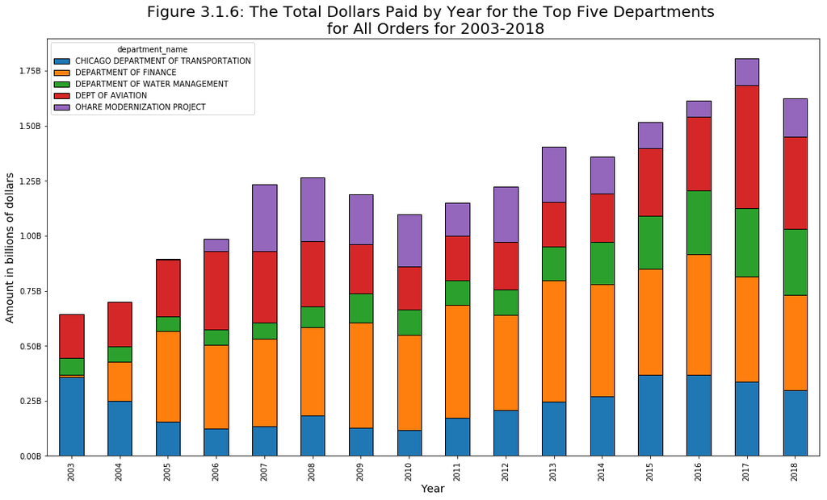

```python
top_five_dept.plot.bar(stacked=True, figsize=(18,10), edgecolor="black")


def billions(val, pos):
    return f'{val*1e-9:.2f}B'

formatter = FuncFormatter(billions)
plt.gca().yaxis.set_major_formatter(formatter)

plt.xlabel("Year", fontsize=14)
plt.ylabel("Amount in billions of dollars", fontsize=14)
plt.title("Figure 3.1.6: The Total Dollars Paid by Year for the Top Five Departments \n for All Orders for 2003-2018", fontsize=20)
cols = top_five_dept.columns.tolist()
cols = ['DEPARTMENT OF FINANCE', 'DEPT OF AVIATION', 'CHICAGO DEPARTMENT OF TRANSPORTATION',
        'DEPARTMENT OF WATER MANAGEMENT', 'OHARE MODERNIZATION PROJECT']
top_five_dept = top_five_dept[cols]
```

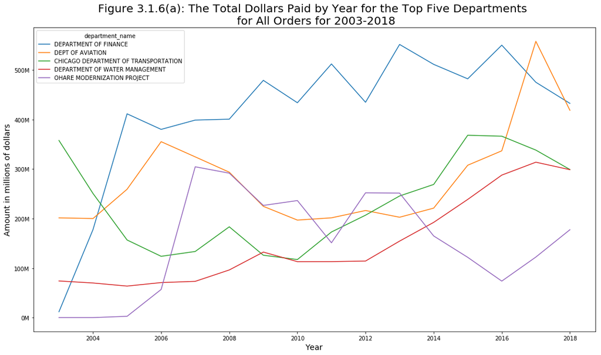

```python
top_five_dept.plot.line( figsize=(18,10))

plt.xlabel("Year", fontsize=14)
plt.ylabel("Amount in millions of dollars", fontsize=14)
plt.title("Figure 3.1.6(a): The Total Dollars Paid by Year for the Top Five Departments \n for All Orders for 2003-2018", fontsize=20)
cols = top_five_dept.columns.tolist()
cols = ['DEPARTMENT OF FINANCE', 'DEPT OF AVIATION', 'CHICAGO DEPARTMENT OF TRANSPORTATION',
        'DEPARTMENT OF WATER MANAGEMENT', 'OHARE MODERNIZATION PROJECT']
top_five_dept = top_five_dept[cols]

def millions(val, pos):
    return f'{val*1e-6:.0f}M'

formatter = FuncFormatter(millions)
plt.gca().yaxis.set_major_formatter(formatter)
```

**Observation: I looked at the changes after Rahm Emanuel took office in 2011. Amount of payments paid by the Department of Water, Transportation Management and Aviation had increased steadly before deeping slightly after 2016.**

```python
water_management_dept = payments_after_2002.loc[(payments_after_2002.department_name ==  "DEPARTMENT OF WATER MANAGEMENT")
                                   & (payments_after_2002.year != 2019)]
```

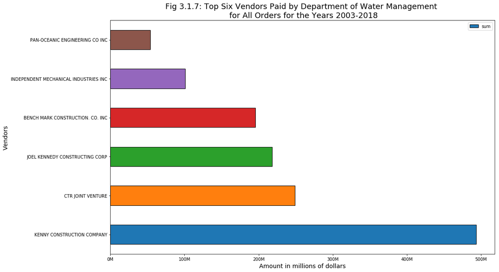

```python
vend = water_management_dept[water_management_dept["vendor_name"].notnull()]

vend = vend.groupby("vendor_name").amount.sum().sort_values(ascending=False).reset_index(name='sum').head(6)
vend.plot.barh(x="vendor_name", y='sum', figsize=(16,10), edgecolor="black")
plt.xlabel("Amount in millions of dollars", fontsize=14)
plt.ylabel("Vendors", fontsize=14)
plt.title("Fig 3.1.7: Top Six Vendors Paid by Department of Water Management \n for All Orders for the Years 2003-2018", fontsize=18)
def millions(val, pos):
    return f'{val*1e-6:.0f}M'

formatter = FuncFormatter(millions)
plt.gca().xaxis.set_major_formatter(formatter)
```

Observation: Kenny Construction Company received the highest amount of payments from the Department of Water Management, almost  
$500 millions.

## 3.2. Analyzing vendors via vizualization.

- *Top 15 vendors* who received the highest amount of payments for all orders for the years 1996-2018 (Fig. 3.2.1).
- *Investigate the vendor that received the highest amount of payments* for all orders for the years 1996-2018 and find out the departments that were financing it (Fig. 3.2.2).
- The Total Dollars Received by year by top four vendors **excluding banks** for all orders for the years 1996-2018 (Fig. 3.2.3).

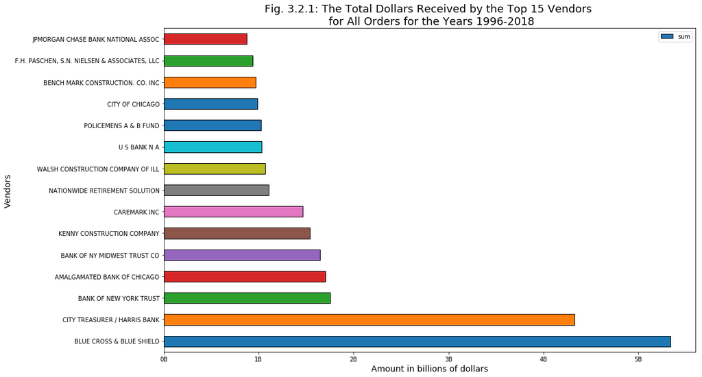

```python
grouped_by_vend = payments[payments["vendor_name"].notnull()]
grouped_by_vend = grouped_by_vend.groupby("vendor_name").amount.sum().sort_values(ascending=False).reset_index(name='sum').head(15)
grouped_by_vend.plot.barh(x="vendor_name", y='sum', figsize=(16,10), edgecolor="black")
plt.xlabel("Amount in billions of dollars", fontsize=14)
plt.ylabel("Vendors", fontsize=14)
plt.title("Fig. 3.2.1: The Total Dollars Received by the Top 15 Vendors \n for All Orders for the Years 1996-2018", fontsize=18)
def billions(val, pos):
    return f'{val*1e-9:.0f}B'

formatter = FuncFormatter(billions)
plt.gca().xaxis.set_major_formatter(formatter)
```

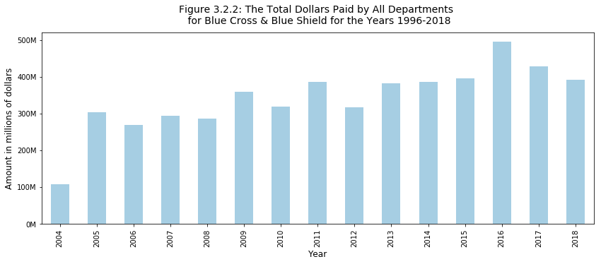

```python
blue_cross = payments.loc[(payments.vendor_name.isin(["BLUE CROSS & BLUE SHIELD"]))&
                                    (payments.year != 2019)]
blue_cross.groupby("year").amount.sum().plot(kind="bar", y="amount", figsize=(14,5), colormap='Paired')

plt.xlabel("Year", fontsize=12)
plt.ylabel("Amount in millions of dollars", fontsize=12)
plt.title('Figure 3.2.2: The Total Dollars Paid by All Departments \n for Blue Cross & Blue Shield for the Years 1996-2018', y=1.02, fontsize=14)
def millions(val, pos):
    return f'{val*1e-6:.0f}M'

formatter = FuncFormatter(millions)
plt.gca().yaxis.set_major_formatter(formatter)
```

*Observation: The highest payments for Blue Cross & Blue Shield was made in 2016.*

```python
blue_cross.department_name.value_counts()
```

```
DEPARTMENT OF FINANCE    61
Name: department_name, dtype: int64
```

*Observation: Department of Finance is the only department that has been financing Blue Cross & Blue Shield in the given data set.*

Note: Consider that we have only 15% available data for the department_name column.

```python
top_five_vend = payments_after_2002.loc[(payments_after_2002.vendor_name.isin(["KENNY CONSTRUCTION COMPANY",
                                                        "CAREMARK INC",
                                                        "NATIONWIDE RETIREMENT SOLUTION",
                                                        "WALSH CONSTRUCTION COMPANY OF ILL"])) &
                            (payments.year != 2019)]

top_five_vend = top_five_vend.groupby(["year","vendor_name"]).amount.sum().unstack()
top_five_vend.fillna(0, inplace=True)
```

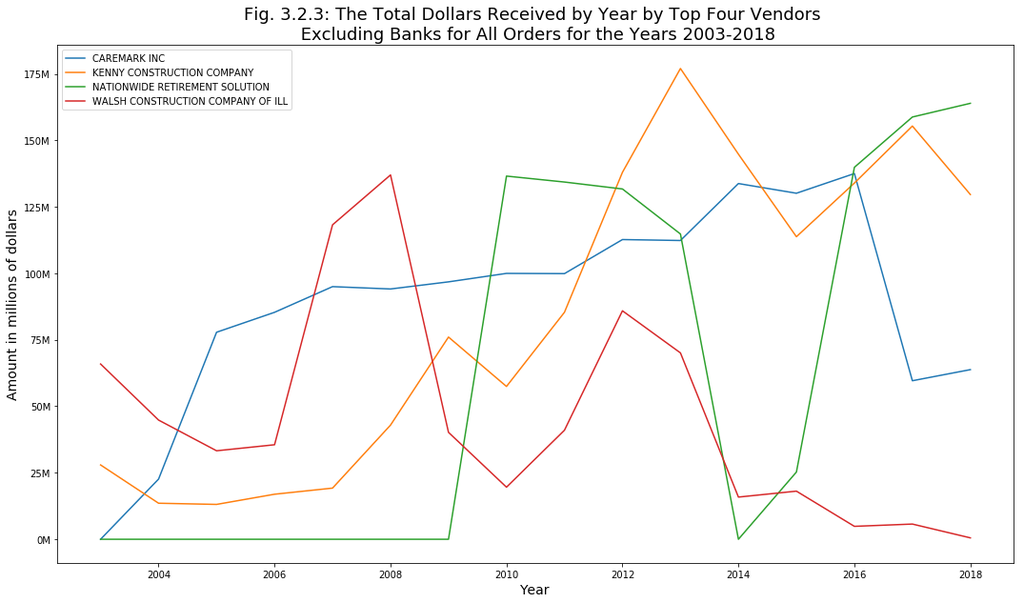

```python
top_five_vend.plot.line( figsize=(18,10))

def millions(val, pos):
    return f'{val*1e-6:.0f}M'

formatter = FuncFormatter(millions)
plt.gca().yaxis.set_major_formatter(formatter)

plt.xlabel("Year", fontsize=14)
plt.ylabel("Amount in millions of dollars", fontsize=14)
plt.title("Fig. 3.2.3: The Total Dollars Received by Year by Top Four Vendors \n Excluding Banks for All Orders for the Years 2003-2018", fontsize=18)
plt.legend(loc=2)
```

*Observation: After a significant raise in 2009, the "Nationwide Retirement Solution" dropped to zero in 2014.*

Note: Top five vendors include mostly banks (look at Fig. 3.2.1)

## 3.3. Analyzing contract and non-contract vendors through vizualization.

- Investigate vendors who received their payment via *contract* or/and *non-contract*.
- The total dollars paid by departments for contract vendors (Fig. 3.3.1).
- The total dollars paid by departments for direct vendors or non-contract (Fig. 3.3.2).
- Analyze departments that were paying without contract.
- Analyze five top vendors that were receiving non-contract payments (Fig. 3.3.3).

```python
payments.contract_number.value_counts().head()
```

```
DV       579610
33233      5252
19393      1691
28775      1559
24027       836
Name: contract_number, dtype: int64
```

```python
payments[payments["contract_number"] == 'DV'].shape[0]/len(payments)
```

```
0.7270061310294309
```

*Observation: Almost 73% of the payments has transactioned to DV (Direct Vendor). I called them non-contract vendors.*

```python
via_contract = payments_after_2002.loc[(payments_after_2002.contract_number != "DV") &
                                      (payments_after_2002.year !=2019)]
```

```python
via_contract.head()
```

|  | amount | department_name | contract_number | vendor_name | cashed | year | month | weekday |
| --- | --- | --- | --- | --- | --- | --- | --- | --- |
| 14 | 16653.00 | NaN | 8627 | PROGRESSIVE INDUSTRIES, INC. | True | 2005 | 1 | 5 |
| 16 | 2685.00 | NaN | 35458 | ROGER J BALLA | True | 2016 | 1 | 4 |
| 27 | 9867.48 | NaN | 19550 | KENNY CONSTRUCTION COMPANY | True | 2018 | 1 | 1 |
| 28 | 250000.00 | PLANNING & DEVELOPMENT | 7585 | CHILDSERV 01 | True | 2010 | 1 | 4 |
| 77 | 9374.30 | CHICAGO DEPARTMENT OF TRANSPORTATION | 44315 | AECOM TECHNICAL SERVICES | True | 2018 | 9 | 2 |

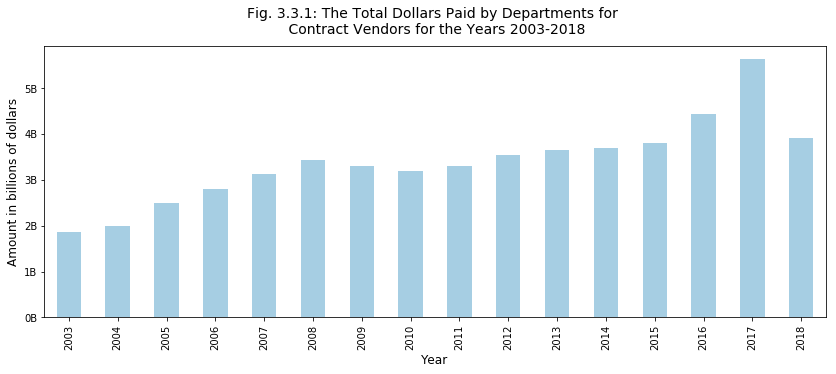

```python
via_contract.groupby("year").amount.sum().plot(kind="bar", colormap="Paired", figsize=(14,5))

plt.xlabel("Year", fontsize=12)
plt.ylabel("Amount in billions of dollars", fontsize=12)
plt.title('Fig. 3.3.1: The Total Dollars Paid by Departments for \n Contract Vendors for the Years 2003-2018', y=1.02, fontsize=14)
def billions(val, pos):
    return f'{val*1e-9:.0f}B'

formatter = FuncFormatter(billions)
plt.gca().yaxis.set_major_formatter(formatter)
```

```python
via_contract.groupby("vendor_name").amount.sum().sort_values(ascending=False).head(10)
```

```
vendor_name
BLUE CROSS & BLUE SHIELD                        5.124513e+09
CAREMARK INC                                    1.421277e+09
KENNY CONSTRUCTION COMPANY                      1.209277e+09
BENCH MARK CONSTRUCTION. CO. INC                8.886829e+08
F.H. PASCHEN, S.N. NIELSEN & ASSOCIATES, LLC    8.145837e+08
BOARD OF EDUCATION OF THE CITY OF CHICAGO       7.644845e+08
WALSH CONSTRUCTION COMPANY OF ILL               7.183408e+08
PUBLIC BUILDING COMMISSION CHICAGO              7.166066e+08
BIGANE PAVING COMPANY                           6.746772e+08
ALLIED WASTE TRANSPORTATION INC                 6.420991e+08
Name: amount, dtype: float64
```

```python
no_contract = payments.loc[(payments.contract_number == "DV") & (payments.year != 2019)]
```

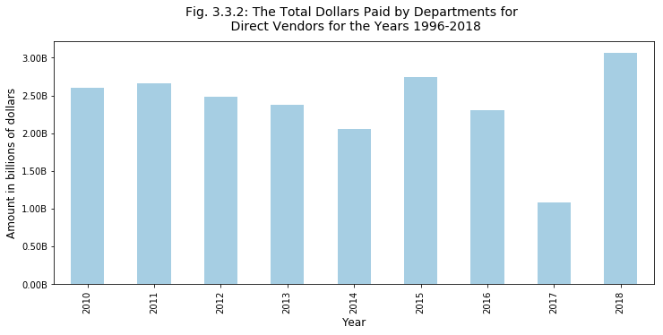

```python
no_contract.groupby("year").amount.sum().plot(kind="bar", colormap="Paired", figsize=(12,5))

plt.xlabel("Year", fontsize=12)
plt.ylabel("Amount in billions of dollars", fontsize=12)
plt.title('Fig. 3.3.2: The Total Dollars Paid by Departments for \n Direct Vendors for the Years 1996-2018', y=1.02, fontsize=14)
def billions(val, pos):
    return f'{val*1e-9:.2f}B'

formatter = FuncFormatter(billions)
plt.gca().yaxis.set_major_formatter(formatter)
```

*Observation: Note that there were no direct payments made before 2010.*

*I wanted to analyze departments that have been paying without contract, but there wasn't any available data.*

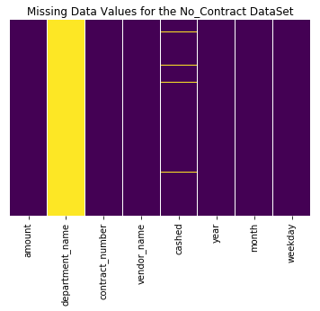

```python
ax = sns.heatmap(no_contract.isnull(),yticklabels=False,cbar=False,cmap='viridis')
ax.set_title("Missing Data Values for the No_Contract DataSet")
```

**463134 rows are missing.**

```python
no_contract.isnull().sum()
```

```
amount                  0
department_name    463134
contract_number         0
vendor_name            10
cashed               7512
year                    0
month                   0
weekday                 0
dtype: int64
```

```python
no_contract.groupby("vendor_name").amount.sum().sort_values(ascending=False).head(25)
```

```
vendor_name
CITY TREASURER / HARRIS BANK                               4.312634e+09
BANK OF NEW YORK TRUST                                     1.466362e+09
AMALGAMATED BANK OF CHICAGO                                1.255046e+09
BANK OF NY MIDWEST TRUST CO                                1.241188e+09
NATIONWIDE RETIREMENT SOLUTION                             1.005149e+09
CITY OF CHICAGO                                            9.909932e+08
POLICEMENS A & B FUND                                      9.502598e+08
JPMORGAN CHASE BANK NATIONAL ASSOC                         7.788749e+08
U S BANK N A                                               6.941353e+08
MUNICIPAL EMPLOYEE PENSION FD                              6.505316e+08
U.S. BANK01 NATIONAL ASSOCIATION                           4.961950e+08
ZIONS BANK                                                 4.397268e+08
FIREMENS ANNUITY BENEFIT FUND                              4.386452e+08
WELLS FARGO BANK N A                                       4.249120e+08
CITY TREASURER 06                                          4.043749e+08
CHICAGO TRANSITY AUTHORITY.                                3.970521e+08
COOK COUNTY TREASURER                                      3.628423e+08
BANK OF AMERICA IL                                         1.592941e+08
MUNICIPAL EMPLOYEES ANNUITY AND BENEFIT FUND OF CHICAGO    1.417950e+08
MUNICIPAL EMPLOY CREDIT UNION                              1.416110e+08
KENNY CONSTRUCTION COMPANY                                 1.356747e+08
O'HARE MODERNIZATION PROGRAM                               1.240411e+08
CHICAGO PARKING METERS LLC                                 1.214796e+08
DEPARTMENT OF AVIATION                                     1.191837e+08
DEUTSCHE BANK TRUST COMPANY                                1.128100e+08
Name: amount, dtype: float64
```

```python
top_five = no_contract.loc[(no_contract.vendor_name.isin(["CITY TREASURER / HARRIS BANK", "POLICEMENS A & B FUND",
                         "NATIONWIDE RETIREMENT SOLUTION", "BANK OF NEW YORK TRUST ", "AMALGAMATED BANK OF CHICAGO",
                        "BANK OF NY MIDWEST TRUST CO" ])) & (no_contract.year != 2019)]

top_five = top_five.groupby(["year","vendor_name"]).amount.sum().unstack()
top_five.fillna(0, inplace=True)
```

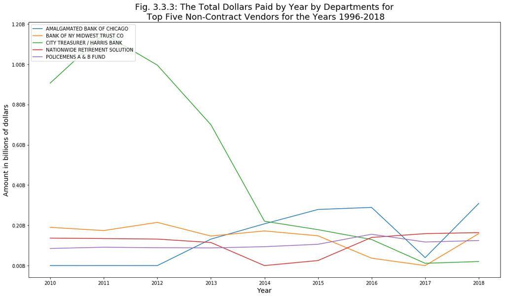

```python
top_five.plot(kind="line", figsize=(18,10))


def billions(val, pos):
    return f'{val*1e-9:.2f}B'

formatter = FuncFormatter(billions)
plt.gca().yaxis.set_major_formatter(formatter)

plt.xlabel("Year", fontsize=14)
plt.ylabel("Amount in billions of dollars", fontsize=14)
plt.title(" Fig. 3.3.3: The Total Dollars Paid by Year by Departments for \n Top Five Non-Contract Vendors for the Years 1996-2018", fontsize=18)
plt.legend(loc=2)
```

# 4. Conclusions

It's difficult to draw any firm conclusions regarding the presence or absence of corruption from the given data, but the structure of many of the transactions as well as key missing data would appear to create an environment where corruption could occur:

The data doesn't show any record for payments that were made with no contract until 2010. I wasn't able to tell if this means that the city only started to allow direct payments after 2010 or that it has all along but didn't distinguish between direct and contract payments before that.

There is no ability to break out the annual payments from 1996-2002, since this data is rolled up as one year. The average annual total payments during this period were just under \$1.6B, which compares to total payments of about \\$1.9B in 2003, the first year the numbers were broken out annually.

I looked at the changes after Rahm Emanuel took office in 2011. Amount of payments paid by the Department of Water, Transportation Management and Aviation had increased steadly before deeping slightly after 2016.

# 5. Suggestions for Further Analysis

I would like to get answers to questions:

- Why are the top vendors that have received the highest amount of payments banks?
- Why doesn't data show us what departments made those payments?
- If banks are just the conduits for payments to others, the ultimate recipients must be revealed.

Departments play an essential role in this data set because they are the ones that make the city's most expenditures. The city has to do a better job of revealing the ultimate recipients for the Payments data, so citizens can validate the transparency and eliminate all the doubts about vague information in the given dataset.